# ANOVA and Post-Hoc Contrasts: Reanalysis of Singmann and Klauer (2011)

Henrik Singmann

2018-09-24

# Overview

This documents reanalysis a dataset from an Experiment performed by Singmann and Klauer (2011) using the ANOVA functionality of **afex** followed by post-hoc tests using package [**emmeans**](https://cran.r-project.org/package=emmeans) (Lenth, 2017). After a brief description of the dataset and research question, the code and results are presented.

# Description of Experiment and Data

Singmann and Klauer (2011) were interested in whether or not conditional reasoning can be explained by a single process or whether multiple processes are necessary to explain it. To provide evidence for multiple processes we aimed to establish a double dissociation of two variables: instruction type and problem type. Instruction type was manipulated between-subjects, one group of participants received deductive instructions (i.e., to treat the premises as given and only draw necessary conclusions) and a second group of participants received probabilistic instructions (i.e., to reason as in an everyday situation; we called this “inductive instruction” in the manuscript). Problem type consisted of two different orthogonally crossed variables that were manipulated within-subjects, validity of the problem (formally valid or formally invalid) and plausibility of the problem (inferences which were consisted with the background knowledge versus problems that were inconsistent with the background knowledge). The critical comparison across the two conditions was among problems which were valid and implausible with problems that were invalid and plausible. For example, the next problem was invalid and plausible:

> If a person is wet, then the person fell into a swimming pool.  
> A person fell into a swimming pool.  
> How valid is the conclusion/How likely is it that the person is wet?

For those problems we predicted that under deductive instructions responses should be lower (as the conclusion does not necessarily follow from the premises) as under probabilistic instructions. For the valid but implausible problem, an example is presented next, we predicted the opposite pattern:

> If a person is wet, then the person fell into a swimming pool.  
> A person is wet.  
> How valid is the conclusion/How likely is it that the person fell into a swimming pool?

Our study also included valid and plausible and invalid and implausible problems.

In contrast to the analysis reported in the manuscript, we initially do not separate the analysis into affirmation and denial problems, but first report an analysis on the full set of inferences, MP, MT, AC, and DA, where MP and MT are valid and AC and DA invalid. We report a reanalysis of our Experiment 1 only. Note that the factor `plausibility` is not present in the original manuscript, there it is a results of a combination of other factors.

# Data and R Preperation

We begin by loading the packages we will be using throughout.

```r
library("afex")     # needed for ANOVA functions.
library("emmeans")  # emmeans must now be loaded explicitly for follow-up tests.
library("multcomp") # for advanced control for multiple testing/Type 1 errors.
library("ggplot2")  # for customizing plots.
afex_options(emmeans_model = "multivariate") # use multivariate model for all follow-up tests.
```

Note that for ANOVAs involving repeated-measures factors, follow-up tests based on the multivariate model are generally preferrably to univariate follow-up tests. Consequently, we set this option globally. Future versions of `afex` will likely use the multivariate model as the default.

```r
data(sk2011.1)
str(sk2011.1)
```

```
## 'data.frame':    640 obs. of  9 variables:
##  $ id          : Factor w/ 40 levels "8","9","10","12",..: 3 3 3 3 3 3 3 3 3 3 ...
##  $ instruction : Factor w/ 2 levels "deductive","probabilistic": 2 2 2 2 2 2 2 2 2 2 ...
##  $ plausibility: Factor w/ 2 levels "plausible","implausible": 1 2 2 1 2 1 1 2 1 2 ...
##  $ inference   : Factor w/ 4 levels "MP","MT","AC",..: 4 2 1 3 4 2 1 3 4 2 ...
##  $ validity    : Factor w/ 2 levels "valid","invalid": 2 1 1 2 2 1 1 2 2 1 ...
##  $ what        : Factor w/ 2 levels "affirmation",..: 2 2 1 1 2 2 1 1 2 2 ...
##  $ type        : Factor w/ 2 levels "original","reversed": 2 2 2 2 1 1 1 1 2 2 ...
##  $ response    : int  100 60 94 70 100 99 98 49 82 50 ...
##  $ content     : Factor w/ 4 levels "C1","C2","C3",..: 1 1 1 1 2 2 2 2 3 3 ...
```

An important feature in the data is that each participant provided two responses for each cell of the design (the content is different for each of those, each participant saw all four contents). These two data points will be aggregated automatically by `afex`.

```r
with(sk2011.1, table(inference, id, plausibility))
```

```
## , , plausibility = plausible
##
##          id
## inference 8 9 10 12 13 15 16 17 18 19 20 21 22 23 24 25 26 27 28 29 30 31 32 33 34 35 36
##        MP 2 2  2  2  2  2  2  2  2  2  2  2  2  2  2  2  2  2  2  2  2  2  2  2  2  2  2
##        MT 2 2  2  2  2  2  2  2  2  2  2  2  2  2  2  2  2  2  2  2  2  2  2  2  2  2  2
##        AC 2 2  2  2  2  2  2  2  2  2  2  2  2  2  2  2  2  2  2  2  2  2  2  2  2  2  2
##        DA 2 2  2  2  2  2  2  2  2  2  2  2  2  2  2  2  2  2  2  2  2  2  2  2  2  2  2
##          id
## inference 37 38 39 40 41 42 43 44 46 47 48 49 50
##        MP  2  2  2  2  2  2  2  2  2  2  2  2  2
##        MT  2  2  2  2  2  2  2  2  2  2  2  2  2
##        AC  2  2  2  2  2  2  2  2  2  2  2  2  2
##        DA  2  2  2  2  2  2  2  2  2  2  2  2  2
##
## , , plausibility = implausible
##
##          id
## inference 8 9 10 12 13 15 16 17 18 19 20 21 22 23 24 25 26 27 28 29 30 31 32 33 34 35 36
##        MP 2 2  2  2  2  2  2  2  2  2  2  2  2  2  2  2  2  2  2  2  2  2  2  2  2  2  2
##        MT 2 2  2  2  2  2  2  2  2  2  2  2  2  2  2  2  2  2  2  2  2  2  2  2  2  2  2
##        AC 2 2  2  2  2  2  2  2  2  2  2  2  2  2  2  2  2  2  2  2  2  2  2  2  2  2  2
##        DA 2 2  2  2  2  2  2  2  2  2  2  2  2  2  2  2  2  2  2  2  2  2  2  2  2  2  2
##          id
## inference 37 38 39 40 41 42 43 44 46 47 48 49 50
##        MP  2  2  2  2  2  2  2  2  2  2  2  2  2
##        MT  2  2  2  2  2  2  2  2  2  2  2  2  2
##        AC  2  2  2  2  2  2  2  2  2  2  2  2  2
##        DA  2  2  2  2  2  2  2  2  2  2  2  2  2
```

# ANOVA

To get the full ANOVA table for the model, we simply pass it to `aov_ez` using the design as described above. We save the returned object for further analysis.

```r
a1 <- aov_ez("id", "response", sk2011.1, between = "instruction",
       within = c("inference", "plausibility"))
```

```
## Contrasts set to contr.sum for the following variables: instruction
```

```r
a1 # the default print method prints a data.frame produced by nice
```

```
## Anova Table (Type 3 tests)
##
## Response: response
##                               Effect           df     MSE         F  ges p.value
## 1                        instruction        1, 38 2027.42      0.31 .003     .58
## 2                          inference 2.66, 101.12  959.12   5.81 **  .06    .002
## 3              instruction:inference 2.66, 101.12  959.12   6.00 **  .07    .001
## 4                       plausibility        1, 38  468.82 34.23 ***  .07  <.0001
## 5           instruction:plausibility        1, 38  468.82  10.67 **  .02    .002
## 6             inference:plausibility  2.29, 87.11  318.91    2.87 + .009     .06
## 7 instruction:inference:plausibility  2.29, 87.11  318.91    3.98 *  .01     .02
## ---
## Signif. codes:  0 '***' 0.001 '**' 0.01 '*' 0.05 '+' 0.1 ' ' 1
##
## Sphericity correction method: GG
```

The equivalent calls (i.e., producing exactly the same output) of the other two ANOVA functions `aov_car` or `aov4` is shown below.

```r
aov_car(response ~ instruction + Error(id/inference*plausibility), sk2011.1)
aov_4(response ~ instruction + (inference*plausibility|id), sk2011.1)
```

The object printed per default for `afex_aov` objects (produced by `nice`) can also be printed nicely using `knitr`:

```r
knitr::kable(nice(a1))
```

| Effect | df | MSE | F | ges | p.value |
| --- | --- | --- | --- | --- | --- |
| instruction | 1, 38 | 2027.42 | 0.31 | .003 | .58 |
| inference | 2.66, 101.12 | 959.12 | 5.81 ** | .06 | .002 |
| instruction:inference | 2.66, 101.12 | 959.12 | 6.00 ** | .07 | .001 |
| plausibility | 1, 38 | 468.82 | 34.23 *** | .07 | <.0001 |
| instruction:plausibility | 1, 38 | 468.82 | 10.67 ** | .02 | .002 |
| inference:plausibility | 2.29, 87.11 | 318.91 | 2.87 + | .009 | .06 |
| instruction:inference:plausibility | 2.29, 87.11 | 318.91 | 3.98 * | .01 | .02 |

Alternatively, the `anova` method for `afex_aov` objects returns a `data.frame` of class `anova` that can be passed to, for example, `xtable` for nice formatting:

```r
print(xtable::xtable(anova(a1), digits = c(rep(2, 5), 3, 4)), type = "html")
```

|  | num Df | den Df | MSE | F | ges | Pr(>F) |
| --- | --- | --- | --- | --- | --- | --- |
| instruction | 1.00 | 38.00 | 2027.42 | 0.31 | 0.003 | 0.5830 |
| inference | 2.66 | 101.12 | 959.12 | 5.81 | 0.063 | 0.0016 |
| instruction:inference | 2.66 | 101.12 | 959.12 | 6.00 | 0.065 | 0.0013 |
| plausibility | 1.00 | 38.00 | 468.82 | 34.23 | 0.068 | 0.0000 |
| instruction:plausibility | 1.00 | 38.00 | 468.82 | 10.67 | 0.022 | 0.0023 |
| inference:plausibility | 2.29 | 87.11 | 318.91 | 2.87 | 0.009 | 0.0551 |
| instruction:inference:plausibility | 2.29 | 87.11 | 318.91 | 3.98 | 0.013 | 0.0177 |

# Post-Hoc Contrasts and Plotting

To further analyze the data we need to pass it to package `emmeans`, a package that offers great functionality for both plotting and contrasts of all kind. A lot of information on `emmeans` can be obtained in [its vignettes](https://cran.r-project.org/package=emmeans) and [faq](https://CRAN.R-project.org/package=emmeans/vignettes/FAQs.html). `emmeans` can work with `afex_aov` objects directly as **afex** comes with the necessary methods for the generic functions defined in `emmeans`. When using the `multivariate` options as described above, `emmeans` uses the ANOVA model estimated via base R’s `lm` method (which in the case of a multivariate response is an object of class `c("mlm", "lm")`). In the default setting (i.e., `emmeans_model = "univariate"`), `emmeans` uses the object created by base R’s `aov` function, which for now is also part of an `afex_aov` object.

## Some First Contrasts

### Main Effects Only

This object can now be passed to `emmeans`, for example to obtain the marginal means of the four inferences:

```r
m1 <- emmeans(a1, ~ inference)
m1
```

```
##  inference   emmean       SE df lower.CL upper.CL
##  MP        87.51250 1.797265 38 83.87413 91.15087
##  MT        76.68125 4.064950 38 68.45219 84.91031
##  AC        69.41250 4.771297 38 59.75351 79.07149
##  DA        82.95625 3.837620 38 75.18740 90.72510
##
## Results are averaged over the levels of: instruction, plausibility
## Confidence level used: 0.95
```

This object can now also be used to compare whether or not there are differences between the levels of the factor:

```r
pairs(m1)
```

```
##  contrast  estimate       SE df t.ratio p.value
##  MP - MT   10.83125 4.331479 38   2.501  0.0759
##  MP - AC   18.10000 5.017994 38   3.607  0.0047
##  MP - DA    4.55625 4.196484 38   1.086  0.7002
##  MT - AC    7.26875 3.983558 38   1.825  0.2778
##  MT - DA   -6.27500 4.702592 38  -1.334  0.5473
##  AC - DA  -13.54375 5.299024 38  -2.556  0.0672
##
## Results are averaged over the levels of: instruction, plausibility
## P value adjustment: tukey method for comparing a family of 4 estimates
```

To obtain more powerful p-value adjustments, we can furthermore pass it to `multcomp` (Bretz, Hothorn, & Westfall, 2011):

```r
summary(as.glht(pairs(m1)), test=adjusted("free"))
```

```
##
##   Simultaneous Tests for General Linear Hypotheses
##
## Linear Hypotheses:
##              Estimate Std. Error t value Pr(>|t|)
## MP - MT == 0   10.831      4.331   2.501  0.05882 .
## MP - AC == 0   18.100      5.018   3.607  0.00475 **
## MP - DA == 0    4.556      4.196   1.086  0.31350
## MT - AC == 0    7.269      3.984   1.825  0.19400
## MT - DA == 0   -6.275      4.703  -1.334  0.31350
## AC - DA == 0  -13.544      5.299  -2.556  0.05882 .
## ---
## Signif. codes:  0 '***' 0.001 '**' 0.01 '*' 0.05 '.' 0.1 ' ' 1
## (Adjusted p values reported -- free method)
```

### A Simple interaction

We could now also be interested in the marginal means of the inferences across the two instruction types. `emmeans` offers two ways to do so. The first splits the contrasts across levels of the factor using the `by` argument.

```r
m2 <- emmeans(a1, "inference", by = "instruction")
## equal: emmeans(a1, ~ inference|instruction)
m2
```

```
## instruction = deductive:
##  inference  emmean       SE df lower.CL  upper.CL
##  MP        97.2875 2.541716 38 92.14206 102.43294
##  MT        70.4000 5.748708 38 58.76235  82.03765
##  AC        61.4875 6.747633 38 47.82763  75.14737
##  DA        81.8125 5.427214 38 70.82568  92.79932
##
## instruction = probabilistic:
##  inference  emmean       SE df lower.CL  upper.CL
##  MP        77.7375 2.541716 38 72.59206  82.88294
##  MT        82.9625 5.748708 38 71.32485  94.60015
##  AC        77.3375 6.747633 38 63.67763  90.99737
##  DA        84.1000 5.427214 38 73.11318  95.08682
##
## Results are averaged over the levels of: plausibility
## Confidence level used: 0.95
```

Consequently, tests are also only performed within each level of the `by` factor:

```r
pairs(m2)
```

```
## instruction = deductive:
##  contrast estimate       SE df t.ratio p.value
##  MP - MT   26.8875 6.125636 38   4.389  0.0005
##  MP - AC   35.8000 7.096515 38   5.045  0.0001
##  MP - DA   15.4750 5.934724 38   2.608  0.0599
##  MT - AC    8.9125 5.633601 38   1.582  0.4007
##  MT - DA  -11.4125 6.650469 38  -1.716  0.3297
##  AC - DA  -20.3250 7.493951 38  -2.712  0.0471
##
## instruction = probabilistic:
##  contrast estimate       SE df t.ratio p.value
##  MP - MT   -5.2250 6.125636 38  -0.853  0.8287
##  MP - AC    0.4000 7.096515 38   0.056  0.9999
##  MP - DA   -6.3625 5.934724 38  -1.072  0.7084
##  MT - AC    5.6250 5.633601 38   0.998  0.7512
##  MT - DA   -1.1375 6.650469 38  -0.171  0.9982
##  AC - DA   -6.7625 7.493951 38  -0.902  0.8036
##
## Results are averaged over the levels of: plausibility
## P value adjustment: tukey method for comparing a family of 4 estimates
```

The second version considers all factor levels together. Consequently, the number of pairwise comparisons is a lot larger:

```r
m3 <- emmeans(a1, c("inference", "instruction"))
## equal: emmeans(a1, ~inference*instruction)
m3
```

```
##  inference instruction    emmean       SE df lower.CL  upper.CL
##  MP        deductive     97.2875 2.541716 38 92.14206 102.43294
##  MT        deductive     70.4000 5.748708 38 58.76235  82.03765
##  AC        deductive     61.4875 6.747633 38 47.82763  75.14737
##  DA        deductive     81.8125 5.427214 38 70.82568  92.79932
##  MP        probabilistic 77.7375 2.541716 38 72.59206  82.88294
##  MT        probabilistic 82.9625 5.748708 38 71.32485  94.60015
##  AC        probabilistic 77.3375 6.747633 38 63.67763  90.99737
##  DA        probabilistic 84.1000 5.427214 38 73.11318  95.08682
##
## Results are averaged over the levels of: plausibility
## Confidence level used: 0.95
```

```r
pairs(m3)
```

```
##  contrast                            estimate       SE df t.ratio p.value
##  MP,deductive - MT,deductive          26.8875 6.125636 38   4.389  0.0020
##  MP,deductive - AC,deductive          35.8000 7.096515 38   5.045  0.0003
##  MP,deductive - DA,deductive          15.4750 5.934724 38   2.608  0.1848
##  MP,deductive - MP,probabilistic      19.5500 3.594529 38   5.439  0.0001
##  MP,deductive - MT,probabilistic      14.3250 6.285536 38   2.279  0.3310
##  MP,deductive - AC,probabilistic      19.9500 7.210470 38   2.767  0.1342
##  MP,deductive - DA,probabilistic      13.1875 5.992910 38   2.201  0.3741
##  MT,deductive - AC,deductive           8.9125 5.633601 38   1.582  0.7577
##  MT,deductive - DA,deductive         -11.4125 6.650469 38  -1.716  0.6772
##  MT,deductive - MP,probabilistic      -7.3375 6.285536 38  -1.167  0.9363
##  MT,deductive - MT,probabilistic     -12.5625 8.129901 38  -1.545  0.7783
##  MT,deductive - AC,probabilistic      -6.9375 8.864434 38  -0.783  0.9931
##  MT,deductive - DA,probabilistic     -13.7000 7.905839 38  -1.733  0.6666
##  AC,deductive - DA,deductive         -20.3250 7.493951 38  -2.712  0.1501
##  AC,deductive - MP,probabilistic     -16.2500 7.210470 38  -2.254  0.3446
##  AC,deductive - MT,probabilistic     -21.4750 8.864434 38  -2.423  0.2600
##  AC,deductive - AC,probabilistic     -15.8500 9.542594 38  -1.661  0.7111
##  AC,deductive - DA,probabilistic     -22.6125 8.659400 38  -2.611  0.1834
##  DA,deductive - MP,probabilistic       4.0750 5.992910 38   0.680  0.9971
##  DA,deductive - MT,probabilistic      -1.1500 7.905839 38  -0.145  1.0000
##  DA,deductive - AC,probabilistic       4.4750 8.659400 38   0.517  0.9995
##  DA,deductive - DA,probabilistic      -2.2875 7.675239 38  -0.298  1.0000
##  MP,probabilistic - MT,probabilistic  -5.2250 6.125636 38  -0.853  0.9885
##  MP,probabilistic - AC,probabilistic   0.4000 7.096515 38   0.056  1.0000
##  MP,probabilistic - DA,probabilistic  -6.3625 5.934724 38  -1.072  0.9588
##  MT,probabilistic - AC,probabilistic   5.6250 5.633601 38   0.998  0.9719
##  MT,probabilistic - DA,probabilistic  -1.1375 6.650469 38  -0.171  1.0000
##  AC,probabilistic - DA,probabilistic  -6.7625 7.493951 38  -0.902  0.9840
##
## Results are averaged over the levels of: plausibility
## P value adjustment: tukey method for comparing a family of 8 estimates
```

### Running Custom Contrasts

Objects returned from `emmeans` can also be used to test specific contrasts. For this, we can simply create a list, where each element corresponds to one contrasts. A contrast is defined as a vector of constants on the reference grid (i.e., the object returned from `emmeans`, here `m3`). For example, we might be interested in whether there is a difference between the valid and invalid inferences in each of the two conditions.

```r
c1 <- list(
  v_i.ded = c(0.5, 0.5, -0.5, -0.5, 0, 0, 0, 0),
  v_i.prob = c(0, 0, 0, 0, 0.5, 0.5, -0.5, -0.5)
  )

contrast(m3, c1, adjust = "holm")
```

```
##  contrast estimate      SE df t.ratio p.value
##  v_i.ded  12.19375 4.11901 38    2.96  0.0105
##  v_i.prob -0.36875 4.11901 38   -0.09  0.9291
##
## Results are averaged over the levels of: plausibility
## P value adjustment: holm method for 2 tests
```

```r
summary(as.glht(contrast(m3, c1)), test = adjusted("free"))
```

```
##
##   Simultaneous Tests for General Linear Hypotheses
##
## Linear Hypotheses:
##               Estimate Std. Error t value Pr(>|t|)
## v_i.ded == 0   12.1937     4.1190    2.96   0.0105 *
## v_i.prob == 0  -0.3687     4.1190   -0.09   0.9291
## ---
## Signif. codes:  0 '***' 0.001 '**' 0.01 '*' 0.05 '.' 0.1 ' ' 1
## (Adjusted p values reported -- free method)
```

The results can be interpreted as in line with expectations. Responses are larger for valid than invalid problems in the deductive, but not the probabilistic condition.

## Plotting

Since version `0.22`, `afex` comes with its own plotting function based on `ggplot2`, `afex_plot`, which works directly with `afex_aov` objects.

As said initially, we are interested in the three-way interaction of instruction with inference, plausibility, and instruction. As we saw above, this interaction was significant. Consequently, we are interested in plotting this interaction.

### Basic Plots

For `afex_plot`, we need to specify the `x`-factor(s), which determine which factor-levels or combinations of factor-levels are plotted on the x-axis. We can also define `trace` factor(s), which determine which factor levels are connected by lines. Finally, we can also define `panel` factor(s), which determine if the plot is split into subplots. `afex_plot` then plots the estimated marginal means obtained from `emmeans`, confidence intervals, and the raw data in the background. Note that the raw data in the background is per default drawn using an alpha blending of .5 (i.e., 50% semi-transparency). Thus, in case of several points lying directly on top of each other, this point appears noticeably darker.

```
## Warning: Panel(s) show a mixed within-between-design.
## Error bars do not allow comparisons across all means.
## Suppress error bars with: error = "none"
```

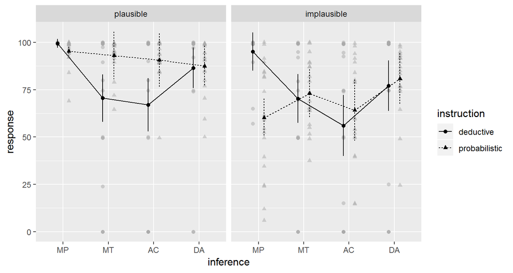

```r
afex_plot(a1, x = "inference", trace = "instruction", panel = "plausibility")
```

In the default settings, the error bars show 95%-confidence intervals based on the standard error of the underlying model (i.e., the `lm` model in the present case). In the present case, in which each subplot (defined by `x`- and `trace`-factor) shows a combination of a within-subjects factor (i.e., `inference`) and a between-subjects (i.e., `instruction`) factor, this is not optimal. The error bars only allow to assess differences regarding the between-subjects factor (i.e., across the lines), but not inferences regarding the within-subjects factor (i.e., within one line). This is also indicated by a warning.

An alternative would be within-subject confidence intervals:

```
## Warning: Panel(s) show a mixed within-between-design.
## Error bars do not allow comparisons across all means.
## Suppress error bars with: error = "none"
```

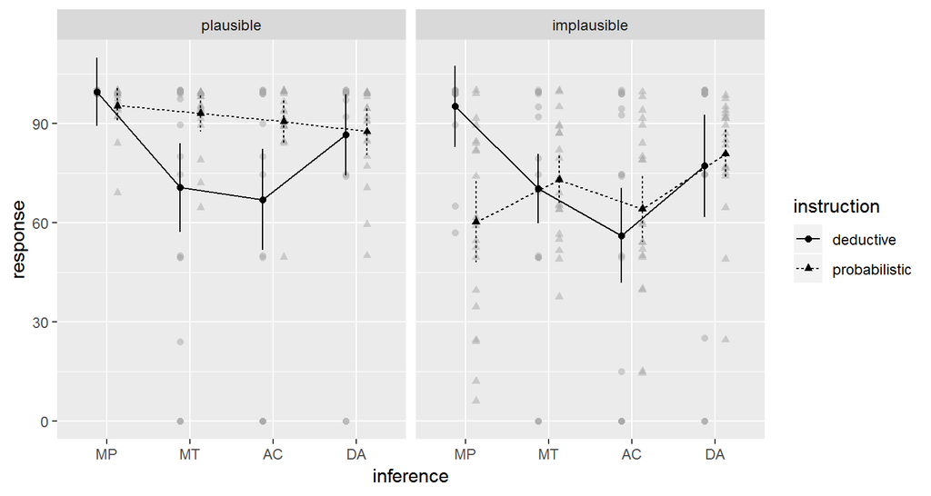

```r
afex_plot(a1, x = "inference", trace = "instruction", panel = "plausibility",
          error = "within")
```

However, those only allow inferences regarding the within-subject factors and not regarding the between-subjecta factor. So the same warning is emitted again.

A further alternative is to suppress the error bars altogether. This is the approach used in our original paper and probably a good idea in general when figures show both between- and within-subjects factors within the same panel. The presence of the raw data in the background still provides a visual depiction of the variability of the data.

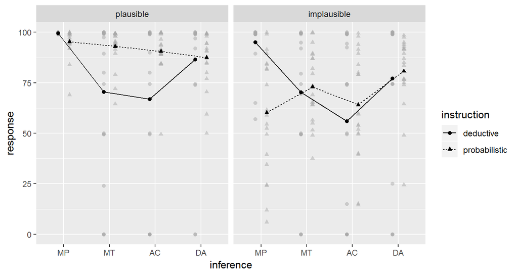

```r
afex_plot(a1, x = "inference", trace = "instruction", panel = "plausibility",
          error = "none")
```

### Customizing Plots

`afex_plot` allows to customize the plot in a number of different ways. For example, we can easily change the aesthetic mapping associated with the `trace` factor. So instead of using lineytpe and shape of the symbols, we can use color. Furthermore, we can change the graphical element used for plotting the data points in the background. For example, instead of plotting the raw data, we can replace this with a boxplot. Finally, we can also make both the points showing the means and the lines connecting the means larger.

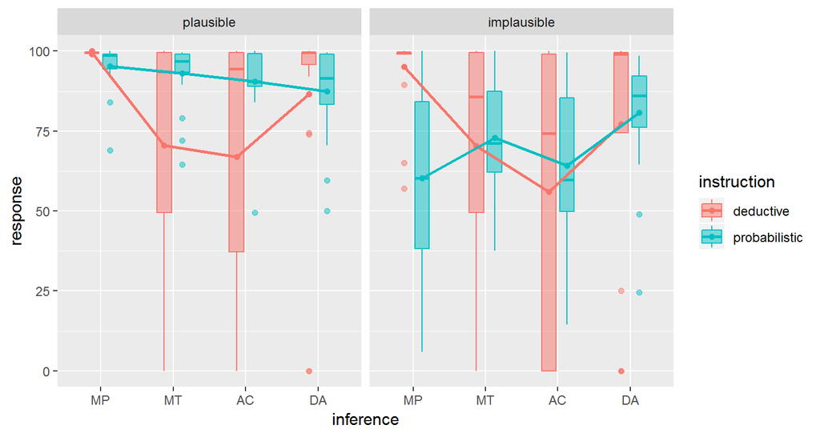

```r
p1 <- afex_plot(a1, x = "inference", trace = "instruction",
                panel = "plausibility", error = "none",
                mapping = c("color", "fill"),
                data_geom = geom_boxplot, data_arg = list(width = 0.4),
                point_arg = list(size = 1.5), line_arg = list(size = 1))
p1
```

Note that `afex_plot` returns a `ggplot2` plot object which can be used for further customization. For example, one can easily change the `theme` to something that does not have a grey background:

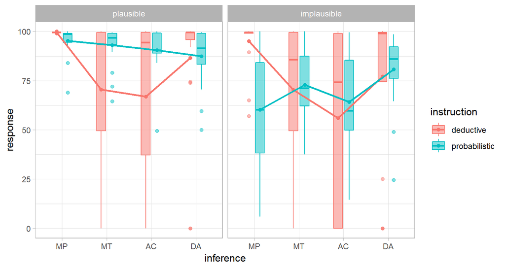

```r
p1 + theme_light()
```

We can also set the theme globally for the remainder of the `R` session.

```r
theme_set(theme_light())
```

The full set of customizations provided by `afex_plot` is beyond the scope of this vignette. The examples on the help page at `?afex_plot` provide a good overview.

# Replicate Analysis from Singmann and Klauer (2011)

However, the plots shown so far are not particularly helpful with respect to the research question. Next, we fit a new ANOVA model in which we separate the data in affirmation and denial inferences. This was also done in the original manuscript. We then lot the data a second time.

```r
a2 <- aov_ez("id", "response", sk2011.1, between = "instruction",
       within = c("validity", "plausibility", "what"))
```

```
## Contrasts set to contr.sum for the following variables: instruction
```

```r
a2
```

```
## Anova Table (Type 3 tests)
##
## Response: response
##                                    Effect    df     MSE         F    ges p.value
## 1                             instruction 1, 38 2027.42      0.31   .003     .58
## 2                                validity 1, 38  678.65    4.12 *    .01     .05
## 3                    instruction:validity 1, 38  678.65    4.65 *    .01     .04
## 4                            plausibility 1, 38  468.82 34.23 ***    .07  <.0001
## 5                instruction:plausibility 1, 38  468.82  10.67 **    .02    .002
## 6                                    what 1, 38  660.52      0.22  .0007     .64
## 7                        instruction:what 1, 38  660.52      2.60   .008     .11
## 8                   validity:plausibility 1, 38  371.87      0.14  .0002     .71
## 9       instruction:validity:plausibility 1, 38  371.87    4.78 *   .008     .04
## 10                          validity:what 1, 38 1213.14   9.80 **    .05    .003
## 11              instruction:validity:what 1, 38 1213.14   8.60 **    .05    .006
## 12                      plausibility:what 1, 38  204.54   9.97 **   .009    .003
## 13          instruction:plausibility:what 1, 38  204.54    5.23 *   .005     .03
## 14             validity:plausibility:what 1, 38  154.62      0.03 <.0001     .85
## 15 instruction:validity:plausibility:what 1, 38  154.62      0.42  .0003     .52
## ---
## Signif. codes:  0 '***' 0.001 '**' 0.01 '*' 0.05 '+' 0.1 ' ' 1
```

Then we plot the data from this ANOVA. Because each panel would again show a mixed-design, we suppress the error bars.

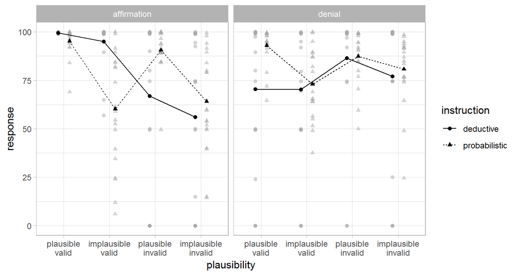

```r
afex_plot(a2, x = c("plausibility", "validity"),
          trace = "instruction", panel = "what",
          error = "none")
```

We see the critical and predicted cross-over interaction in the left of those two graphs. For implausible but valid problems deductive responses are larger than probabilistic responses. The opposite is true for plausible but invalid problems. We now tests these differences at each of the four x-axis ticks in each plot using custom contrasts (`diff_1` to `diff_4`). Furthermore, we test for a validity effect and plausibility effect in both conditions.

```r
(m4 <- emmeans(a2, ~instruction+plausibility+validity|what))
```

```
## what = affirmation:
##  instruction   plausibility validity emmean       SE df lower.CL  upper.CL
##  deductive     plausible    valid    99.475 1.160727 38 97.12523 101.82477
##  probabilistic plausible    valid    95.300 1.160727 38 92.95023  97.64977
##  deductive     implausible  valid    95.100 5.007815 38 84.96221 105.23779
##  probabilistic implausible  valid    60.175 5.007815 38 50.03721  70.31279
##  deductive     plausible    invalid  66.950 6.950663 38 52.87912  81.02088
##  probabilistic plausible    invalid  90.550 6.950663 38 76.47912 104.62088
##  deductive     implausible  invalid  56.025 7.972665 38 39.88518  72.16482
##  probabilistic implausible  invalid  64.125 7.972665 38 47.98518  80.26482
##
## what = denial:
##  instruction   plausibility validity emmean       SE df lower.CL  upper.CL
##  deductive     plausible    valid    70.550 6.181540 38 58.03613  83.06387
##  probabilistic plausible    valid    92.975 6.181540 38 80.46113 105.48887
##  deductive     implausible  valid    70.250 6.355033 38 57.38491  83.11509
##  probabilistic implausible  valid    72.950 6.355033 38 60.08491  85.81509
##  deductive     plausible    invalid  86.525 5.318808 38 75.75764  97.29236
##  probabilistic plausible    invalid  87.450 5.318808 38 76.68264  98.21736
##  deductive     implausible  invalid  77.100 6.617466 38 63.70364  90.49636
##  probabilistic implausible  invalid  80.750 6.617466 38 67.35364  94.14636
##
## Confidence level used: 0.95
```

```r
c2 <- list(
  diff_1 = c(1, -1, 0, 0, 0, 0, 0, 0),
  diff_2 = c(0, 0, 1, -1, 0, 0, 0, 0),
  diff_3 = c(0, 0, 0, 0,  1, -1, 0, 0),
  diff_4 = c(0, 0, 0, 0,  0, 0, 1, -1),
  val_ded  = c(0.5, 0, 0.5, 0, -0.5, 0, -0.5, 0),
  val_prob = c(0, 0.5, 0, 0.5, 0, -0.5, 0, -0.5),
  plau_ded   = c(0.5, 0, -0.5, 0, -0.5, 0, 0.5, 0),
  plau_prob  = c(0, 0.5, 0, -0.5, 0, 0.5, 0, -0.5)
  )
contrast(m4, c2, adjust = "holm")
```

```
## what = affirmation:
##  contrast  estimate        SE df t.ratio p.value
##  diff_1      4.1750  1.641515 38   2.543  0.0759
##  diff_2     34.9250  7.082119 38   4.931  0.0001
##  diff_3    -23.6000  9.829721 38  -2.401  0.0854
##  diff_4     -8.1000 11.275051 38  -0.718  0.9538
##  val_ded    35.8000  7.096515 38   5.045  0.0001
##  val_prob    0.4000  7.096515 38   0.056  0.9553
##  plau_ded   -3.2750  3.065092 38  -1.068  0.8761
##  plau_prob  30.7750  4.992400 38   6.164  <.0001
##
## what = denial:
##  contrast  estimate        SE df t.ratio p.value
##  diff_1    -22.4250  8.742017 38  -2.565  0.1007
##  diff_2     -2.7000  8.987374 38  -0.300  1.0000
##  diff_3     -0.9250  7.521931 38  -0.123  1.0000
##  diff_4     -3.6500  9.358510 38  -0.390  1.0000
##  val_ded   -11.4125  6.650469 38  -1.716  0.5658
##  val_prob   -1.1375  6.650469 38  -0.171  1.0000
##  plau_ded   -4.5625  4.114603 38  -1.109  1.0000
##  plau_prob  13.3625  2.957010 38   4.519  0.0005
##
## P value adjustment: holm method for 8 tests
```

We can also pass these tests to `multcomp` which gives us more powerful Type 1 error corrections.

```r
summary(as.glht(contrast(m4, c2)), test = adjusted("free"))
```

```
## Warning in tmp$pfunction("adjusted", ...): Completion with error > abseps

## Warning in tmp$pfunction("adjusted", ...): Completion with error > abseps

## Warning in tmp$pfunction("adjusted", ...): Completion with error > abseps

## Warning in tmp$pfunction("adjusted", ...): Completion with error > abseps

## Warning in tmp$pfunction("adjusted", ...): Completion with error > abseps

## Warning in tmp$pfunction("adjusted", ...): Completion with error > abseps

## Warning in tmp$pfunction("adjusted", ...): Completion with error > abseps
```

```
## $`what = affirmation`
##
##   Simultaneous Tests for General Linear Hypotheses
##
## Linear Hypotheses:
##                Estimate Std. Error t value Pr(>|t|)
## diff_1 == 0       4.175      1.641   2.543   0.0650 .
## diff_2 == 0      34.925      7.082   4.931 8.43e-05 ***
## diff_3 == 0     -23.600      9.830  -2.401   0.0705 .
## diff_4 == 0      -8.100     11.275  -0.718   0.6882
## val_ded == 0     35.800      7.096   5.045 6.85e-05 ***
## val_prob == 0     0.400      7.096   0.056   0.9553
## plau_ded == 0    -3.275      3.065  -1.068   0.6036
## plau_prob == 0   30.775      4.992   6.164 5.62e-06 ***
## ---
## Signif. codes:  0 '***' 0.001 '**' 0.01 '*' 0.05 '.' 0.1 ' ' 1
## (Adjusted p values reported -- free method)
##
##
## $`what = denial`
##
##   Simultaneous Tests for General Linear Hypotheses
##
## Linear Hypotheses:
##                Estimate Std. Error t value Pr(>|t|)
## diff_1 == 0     -22.425      8.742  -2.565  0.08088 .
## diff_2 == 0      -2.700      8.987  -0.300  0.98492
## diff_3 == 0      -0.925      7.522  -0.123  0.98492
## diff_4 == 0      -3.650      9.358  -0.390  0.98492
## val_ded == 0    -11.412      6.651  -1.716  0.37955
## val_prob == 0    -1.137      6.651  -0.171  0.98492
## plau_ded == 0    -4.562      4.115  -1.109  0.72589
## plau_prob == 0   13.363      2.957   4.519  0.00044 ***
## ---
## Signif. codes:  0 '***' 0.001 '**' 0.01 '*' 0.05 '.' 0.1 ' ' 1
## (Adjusted p values reported -- free method)
```

Unfortunately, in the present case this function throws several warnings. Nevertheless, the p-values from both methods are very similar and agree on whether or not they are below or above .05. Because of the warnings it seems advisable to use the one provided by `emmeans` directly and not use the ones from `multcomp`.

# Some Cautionary Notes

- Choosing the right correction for multiple testing can be difficult. In fact `multcomp` comes with an accompanying book (Bretz et al., 2011). If the degrees-of-freedom of all contrasts are identical using `multcomp`’s method `free` is more powerful than simply using the Bonferroni-Holm method. `free` is a generalization of the Bonferroni-Holm method that takes the correlations among the model parameters into account and uniformly more powerful.
- For data sets with many within-subject factors, creating the `aov` object can take some time (i.e., compared to producing the ANOVA table which is usually very fast). Those objects are also comparatively large, often multiple MB. If speed is important and one is not interested in employing `emmeans` one can set `return = "nice"` in the call to the ANOVA function to only receive the ANOVA table (this can also be done globally: `afex_options(return_aov = "nice")`).

# References

- Bretz, F., Hothorn, T., & Westfall, P. H. (2011). *Multiple comparisons using R*. Boca Raton, FL: CRC Press. https://CRAN.R-project.org/package=multcomp
- Singmann, H., & Klauer, K. C. (2011). Deductive and inductive conditional inferences: Two modes of reasoning. *Thinking & Reasoning*, 17(3), 247-281. doi: 10.1080/13546783.2011.572718
- Lenth, R. (2017). *emmeans: Estimated Marginal Means, aka Least-Squares Means*. R package version 0.9.1. https://CRAN.R-project.org/package=emmeans